# Projet Statistiques industrielles

Pape Saliou FALL

#### **Première approche de résolution du cas d’étude détermination de la hauteur de la digue**

On dispose d’une base d’enregistrements historiques, sur 149 années (entre 1849 et 1997), des débits maxima annuels de crue Q et des hauteurs d’eau associées H, certaines données étant manquantes.

l’objectif du travail consiste à proposer une hauteur de digue 𝒽d de façon à “minimiser le risque d’inondation”, c’est-à-dire la probabilité que H−𝒽d soit positive à partir des seuls relevés de mesure historiques.

#### **Statistiques descriptives**

- **Valeurs manques**

```
## [1] 26
```

On a 26 valeurs manquantes

- **Boxplot de la hauteur**

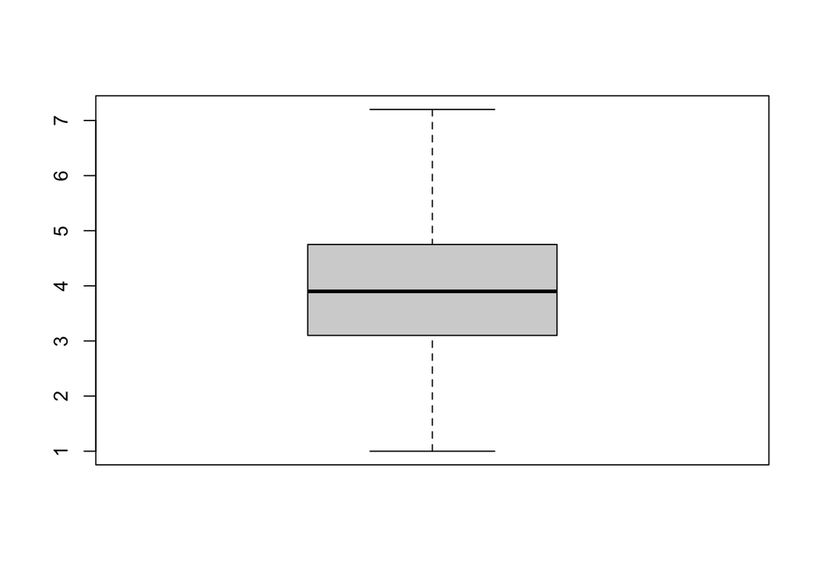

Nous constatons d’après le Boxplot la majeur partie du temps les hauteurs de l’eau sont entre " 3 et 5 m.

```
## [1] 3.896748
```

la valeur moyenne des hauteurs de l’eau est 3.89 m.

```
## [1] 7.2
```

La valeur maximale des hauteurs de l’eau est 7.2 m.

- **Nuage de points de la hauteur de l’eau en fonction du debit**

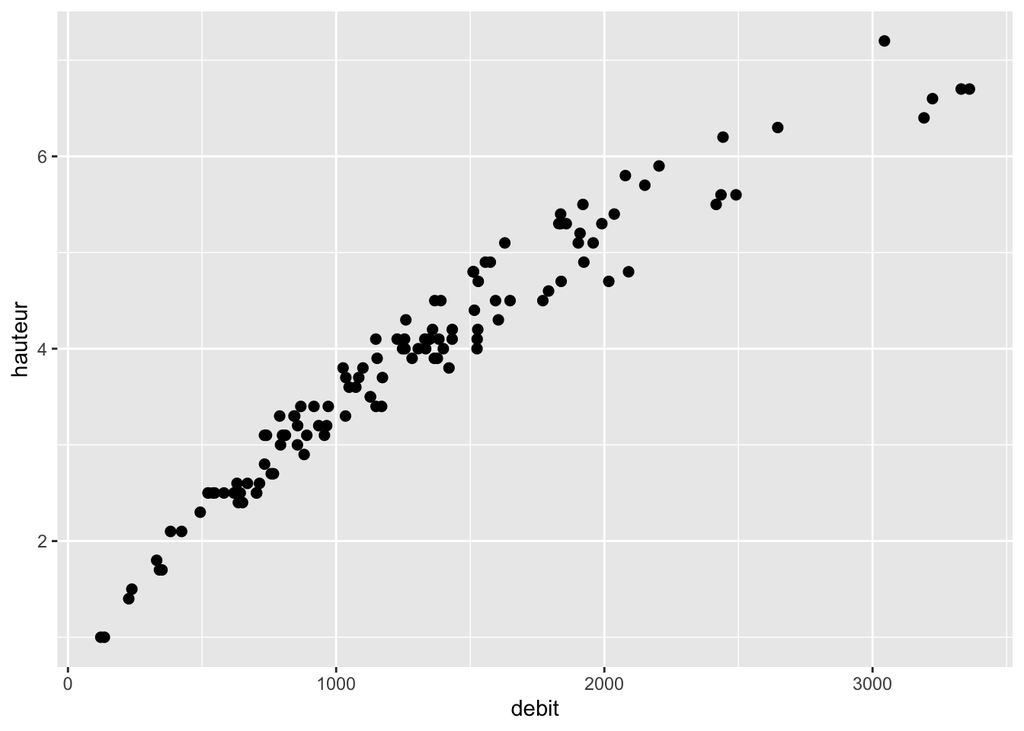

D’après le graphique il semble exister une relation lineaire entre la hauteur et le débit.

On peut faire un test de corrélation pour s’en convaincre.

- **L’ajustement du nuage point de la hauteur en fonction du débit par un polynome de degré 2**

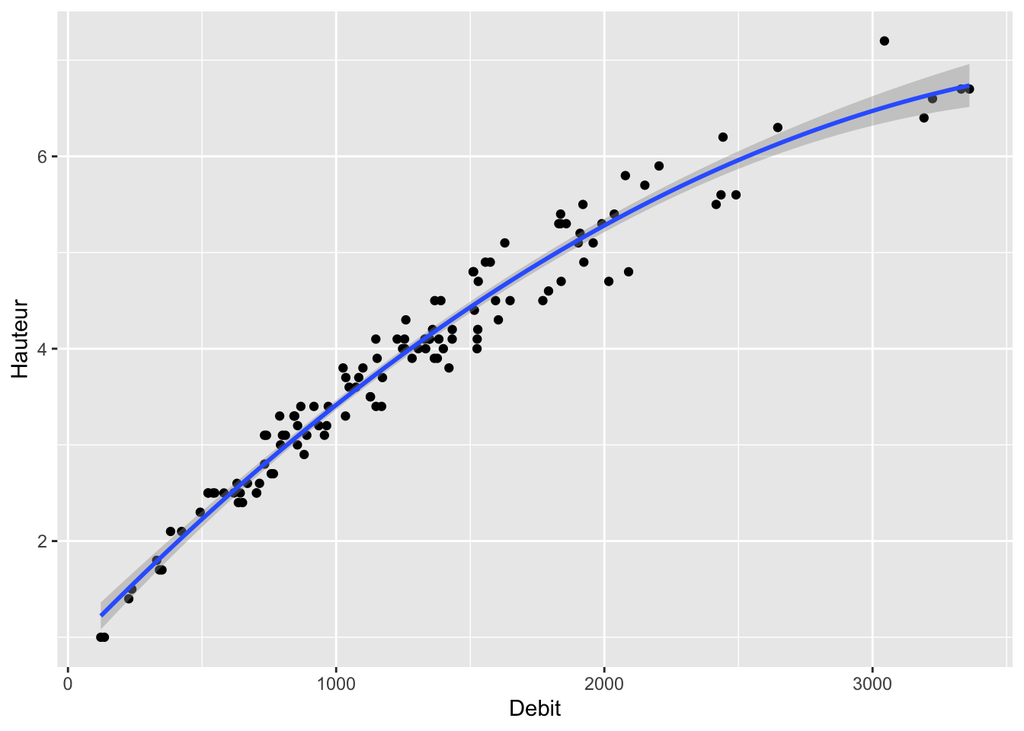

Maintenant nous pouvons remplacer les valeurs manquantes à l’aide du polynome de regression.

```r
cor(donne)
```

```
##              Année      debit    hauteur
## Année    1.0000000 -0.1635042 -0.1825828
## debit   -0.1635042  1.0000000  0.9647020
## hauteur -0.1825828  0.9647020  1.0000000
```

- **Histogramme de la hauteur**

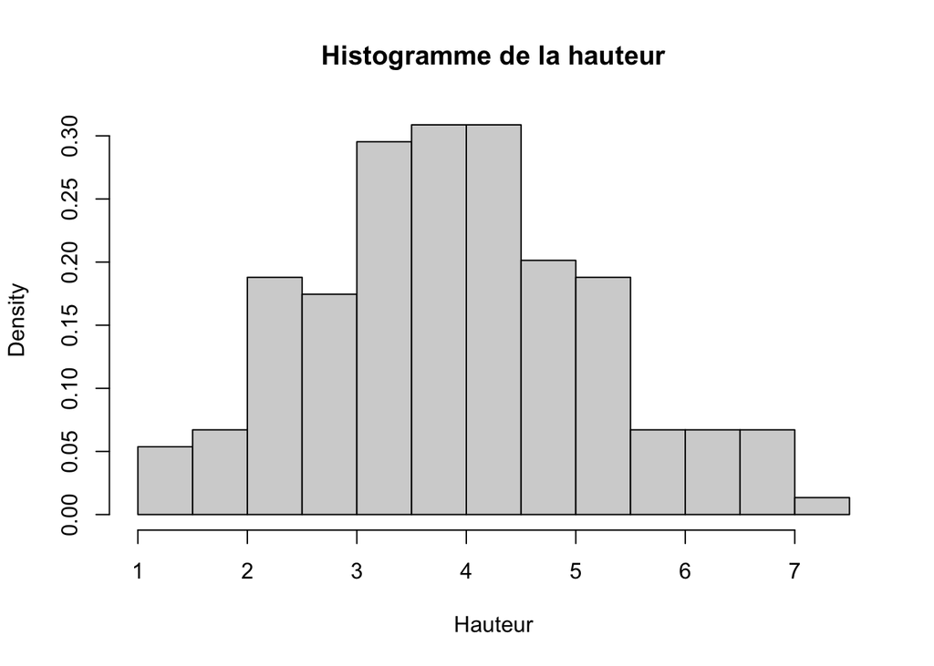

D’après le graphique la hauteur semble suivre une loi normale. On va essayer d’estimer les parametres à l’aide du maximum de vraisemblance.

```
##     mean       sd
## 3.945150 1.281405
```

- **Test de Kolmogorov-Smirnov**

```
## [1] 0.928853
```

On a une p-value de 0.928853 donc on accepte l’hypothèse selon laquelle l’hauteur suit une loi normale.

Alors on peut calculer la hauteur:

$P( H - hd > 0)$ = $1 - P( H < hd ) = 1 - F(hd)$

On a vu dans une revue sur internet que dans les zones sensibles comme les grands barrages et les centrales nicléaires on a comme norme un risque de $10^{-4}$ voire au-delà.

En prenant hd comme le quantile d’ordre 0.99999 on trouve une valeur 9.017869 avec un risque de $10^{-5}$.

Donc $hd = 9.017869$ m et avec risque $10^{-5}$.

### **Seconde approche à partir du modèle hydraulique**

Nous obtenons donc l’estimation suivante de **P(S>0)** selon différentes valeurs de **hd**.

| hd | P(S>hd) |
| --- | --- |
| 1.00 | 0.0032077 |
| 2.00 | 0.0009022 |
| 3.00 | 0.0004010 |
| 4.00 | 0.0004010 |
| 5.00 | 0.0003007 |
| 6.00 | 0.0003007 |
| 7.00 | 0.0001002 |
| 7.20 | 0.0001002 |
| 7.25 | 0.0001002 |
| 8.00 | 0.0000000 |
| 9.00 | 0.0000000 |

La meilleure valeur semble être $7.25$. On remarque que cette valeur est très proche du maximum des hauteur de digue présentes dans la première méthodes.

### **Troisième méthode**

| hauteur | cmoy |
| --- | --- |
| 1 | 2637341.5 |
| 2 | 964072.3 |
| 3 | 927703.4 |
| 4 | 781271.6 |
| 5 | 857133.3 |
| 6 | 511148.7 |
| 7 | 327320.4 |
| 8 | 367416.5 |
| 9 | 418240.9 |

[output not shown]